# Module 08: Visualizing Wrangled Data

Plot the table you built and checked. Every aesthetic is a decision.

Chris Chizinski

## Slide Accessibility Note

- **Images:** every figure has alt text; diagrams are HTML text with labels.
- **Speaker Notes:** These slides follow the Module 08 follow-along script and the book chapter Visualizing Wrangled Data. The live coding happens in `class/week_08_follow_along.R`.

## Today

Cleaned, checked table

->

`ggplot(aes())`

->

Geom by data type

->

Facets, scales, labels

->

Caption states the pattern

After the break: joining two tables, then one figure in your project report.

- **Proposal due Sun Nov 15**, 11:59 PM
- **Draft due Sun Nov 29:** needs **3 figures**. Today is practice for them.

## Your Project: Where We Are

|  | When | Project step |
| --- | --- | --- |
| ☑ Done | Mon Oct 26 | Create your project repo; invite the instructor and your reviewer |
| ☑ Done | Mon Nov 2 | Data audit: import, `clean_names()`, column types, missing values |
| ▶ **This week** | Mon Nov 9 | First figure in `report.qmd`, with `fig-cap` and `fig-alt` |
| ▶ **This week** | Sun Nov 15 | **Proposal due** (rendered and pushed) |
| ☐ To do | Mon Nov 16 | One summary table and one inline number in `report.qmd` |
| ☐ To do | Mon Nov 23 | Project workshop: draft checklist, fresh-clone render test |
| ☐ To do | Sun Nov 29 | **Draft due:** every section started, 3 figures |
| ☐ To do | Mon Nov 30 | Peer review in class: clone, render, start the review Issue |
| ☐ To do | Wed Dec 2 | Review Issue filed on your peer’s repo |
| ☐ To do | Mon Dec 7 | Revision workshop (last class) |
| ☐ To do | Sun Dec 13 | Reply to every comment on the review Issue |
| ☐ To do | Wed Dec 16 | **Final due:** last push plus the `v1.0` tag |

## Get Today’s Files: Pull

I added two files to your **Module 05** repo on GitHub: `class/week_08_follow_along.R` and `class/data/stocked.csv`.

**GitHub Desktop**

1. Commit anything changed
2. **Fetch origin**
3. **Pull origin**

**Positron**

1. Missed Oct 26? Once, in the Terminal:  
   `git config --global pull.rebase false`
2. Source Control: commit anything changed
3. **…** menu > **Pull**

## Stuck On The Pull?

| You see | Do this |
| --- | --- |
| Positron: “reconcile **divergent branches**” | Terminal: `git pull --no-rebase --no-edit`, then push |
| No Pull option / “not a git repository” | Open the Module 05 repo folder |
| Anything else after 3 minutes | Download both files below into `class/` and `class/data/` |

Download the Module 08 follow-along script (.R)

[Download stocked.csv from TidyTuesday (7.3 MB)](https://raw.githubusercontent.com/rfordatascience/tidytuesday/main/data/2021/2021-06-08/stocked.csv)

## Setup Check

1. **Session > Restart R**
2. Open `class/week_08_follow_along.R`, run Section 0
3. `dim(fishing)` **65706 7** and `dim(stocked)` **56232 31**

## Learning Goals

- Build a plot from its three parts: **data, aesthetics, geom**
- Tell an **aesthetic** (mapped from a column) from a **setting** (one fixed value)
- Pick a geom by **data type**; use **facets**, **log scales**, **units**, and a **colorblind-safe** palette
- Join two tables by a **key**, and **audit** the join with row counts and `anti_join()`
- Put a figure with `fig-cap` and `fig-alt` in your project report

## The Data: Great Lakes, Again

| File | One row is | Units | You met it in |
| --- | --- | --- | --- |
| `fishing.csv` | lake, year, species, region | catch, **thousands of pounds** | Module 05 |
| `stocked.csv` | one stocking event | number of fish | Module 04 |

Both from the Great Lakes Fishery Commission, via TidyTuesday 2021-06-08.

**Story for today:** lake trout collapsed around 1950. Managers started stocking. Did catch come back?

## Recap: Build The Table First

Module 05 trap: **total rows** sit on top of area rows.

```r
lake_catch <- fishing |>
  mutate(region = str_trim(region)) |>
  filter(region %in% lake_totals) |>      # U.S. + Canada total rows only
  group_by(lake, year, species) |>
  summarize(catch = sum(values, na.rm = TRUE), .groups = "drop")
```

`lake_totals` is the list of five total-row names, given complete in Section 1 of your script.

**CHECK:** `nrow(lake_catch)` **12047**; `trout` has **606** rows.

## Three Parts, Every Plot

```r
ggplot(trout, aes(x = year, y = catch, color = lake)) +
  geom_line()
```

| Part | In this code | What it decides |
| --- | --- | --- |
| **Data** | `trout` | a tidy table you already checked |
| **Aesthetics** | `aes(x = year, y = catch, color = lake)` | which **column** goes to which visual property |
| **Geom** | `geom_line()` | what shape draws it |

Layers join with **`+`**, not `|>`.

## What Happened Around 1950?

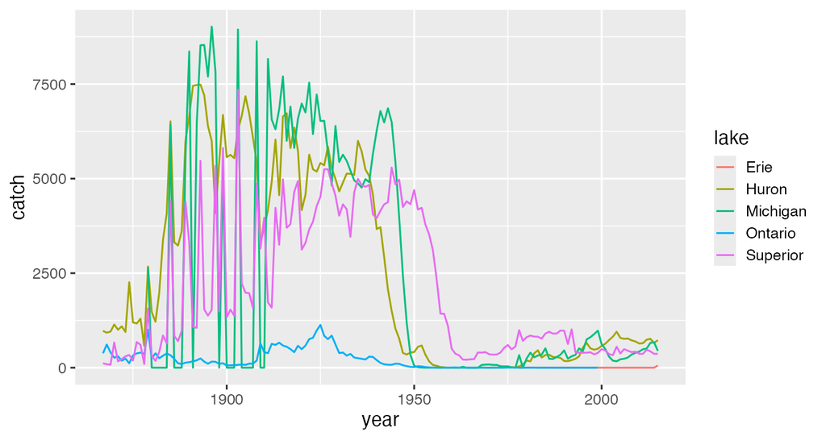

## Aesthetic Or Setting?

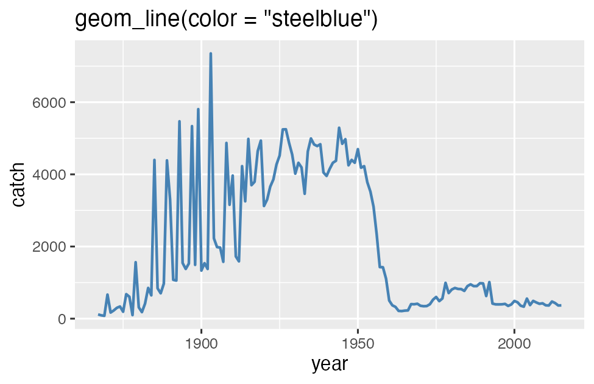

**Setting**, outside `aes()`: one fixed value.

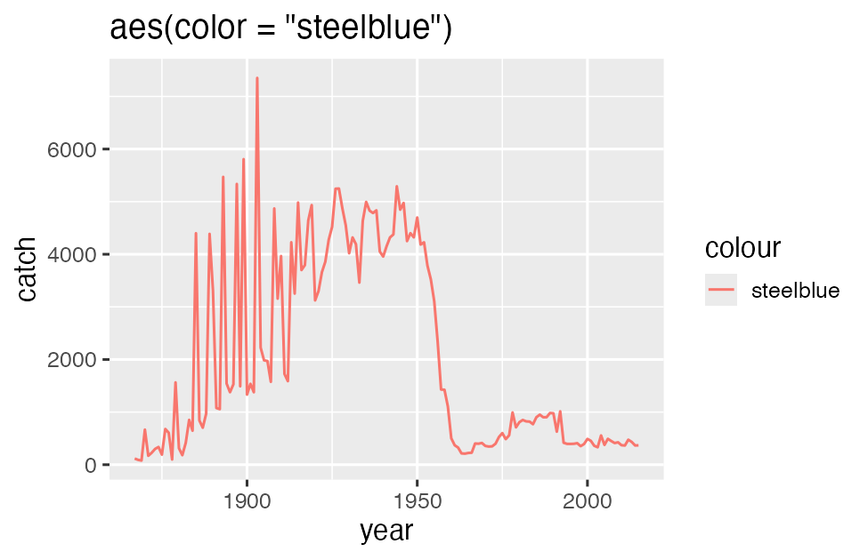

Inside `aes()`: R **maps** a fake column whose every value is the word “steelblue”.

## Labels With Units

```r
labs(
  x = NULL,
  y = "Commercial catch (thousands of pounds)",
  color = "Lake",
  title = "Lake trout catch collapsed around 1950"
)
```

- `x = NULL` removes the axis title: years need no label
- The project rubric checks **units on every axis**
- A title that **states the finding** beats “Lake trout by year”

## Challenge 1 (15 min)

- **Step 1 (everyone):** lake whitefish catch over time, one line per lake, y label with units. Which lake led in **2015**? **CHECK: Huron, 3444**
- **Step 2 (Step 1 matches):** Lake Michigan whitefish only, one fixed line color, thicker line. Setting or aesthetic?

## Challenge 1: Hint 1, The Plan

**Step 1**

1. Start from `lake_catch`, not `trout`
2. `filter()` the species: `"Lake Whitefish"`
3. Pipe into the same `ggplot()` + `geom_line()` + `labs()`
4. For the CHECK: `filter(year == 2015)`, `arrange(desc(catch))`

**Step 2**

1. Add `lake == "Michigan"` to the same `filter()`
2. Remove `color = lake` from `aes()`
3. Put `color = "..."` and `linewidth = 1` **inside** `geom_line()`

Still stuck? **Hint 2** is in the book: [Visualizing Wrangled Data, In-Class Challenge Hints](https://nres800-fall2026.netlify.app/chapters/08-visualizing-wrangled-data.html#in-class-challenge-hints) (book chapter 11).

## Pick The Geom By The Data

| Your data | Geom | Today's example |
| --- | --- | --- |
| a number over time | `geom_line()` | catch by year |
| one number per category | `geom_col()` | total catch by lake |
| distribution of one number | `geom_histogram()`, `geom_boxplot()` | fish per stocking event |
| two numbers | `geom_point()` | fish stocked vs catch |

`geom_col()` plots a number you already have. `geom_bar()` **counts rows** for you.

## Where Is Lake Ontario?

```r
trout |> filter(year >= 2000) |> group_by(lake) |>
  summarize(total = sum(catch)) |>
  ggplot(aes(x = lake, y = total)) + geom_col()
```

**Four bars.** Ontario’s catch rows **end in 1999**.

A missing bar is not a zero bar. **Say so in the caption.**

## Scales: When Everything Piles Up

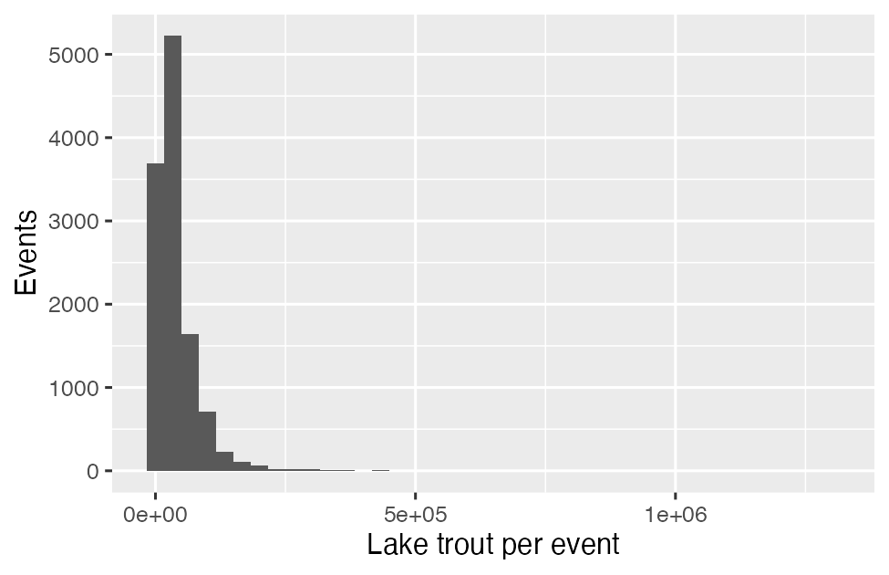

Median **27,167** fish, max **1,300,000**

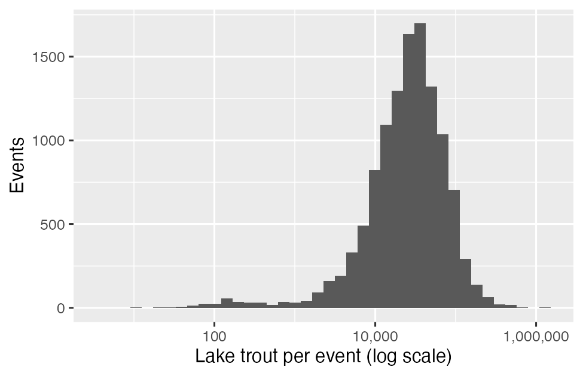

`scale_x_log10()`. log cannot show 0: drop zeros (**1** event) and say so.

## Facets: One Panel Per Group

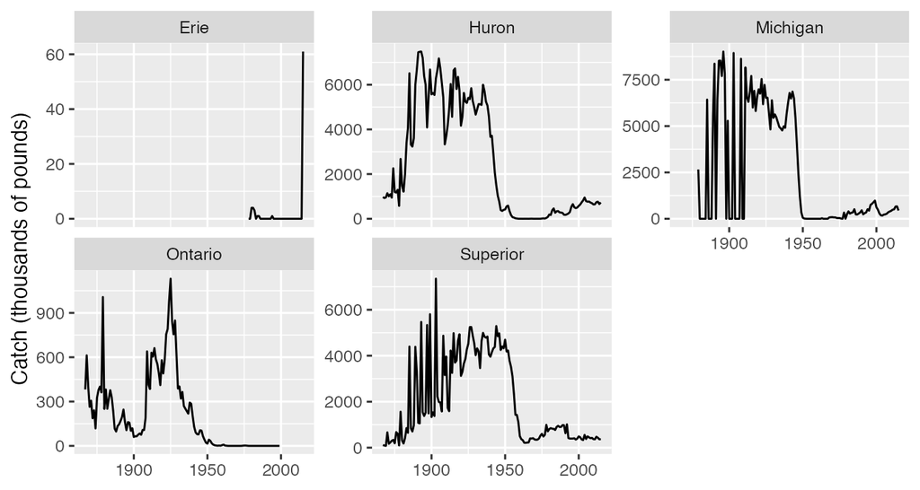

`facet_wrap(~ lake, scales = "free_y")`. With **free_y**, panel heights are not comparable: **say so in the caption**.

## Color Everyone Can Read

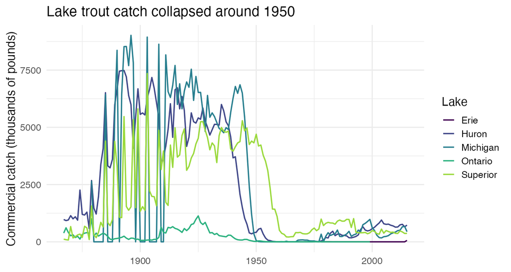

`scale_color_viridis_d(end = 0.85)`: colorblind-safe, no pale yellow. Color should **never be the only way** to read a plot: facets or labels back it up.

## Challenge 2 (15 min)

- **Step 1 (everyone):** boxplot of lake trout per stocking event (`species == "LAT"`), one box per lake, log y axis, zeros removed. Largest median? **CHECK: MI, 50400**
- **Step 2 (Step 1 matches, or at home):** lake trout stocked per year in **millions**, bars, one panel per lake. Biggest lake-year?

## Challenge 2: Hint 1, The Plan

**Step 1**

1. `stocked`, `filter()` species **and** `no_stocked > 0`
2. `aes(x = lake, y = no_stocked)`, `geom_boxplot()`
3. Log scale on **y**: `scale_y_log10()`
4. CHECK: `group_by(lake)`, `summarize(median(no_stocked))`

**Step 2**

1. `group_by(lake, year)`, `summarize(sum(no_stocked) / 1e6)`
2. One number per category: which geom?
3. `facet_wrap(~ lake)`

Still stuck? **Hint 2** is in the book: [Visualizing Wrangled Data, In-Class Challenge Hints](https://nres800-fall2026.netlify.app/chapters/08-visualizing-wrangled-data.html#in-class-challenge-hints) (book chapter 11).

## Break (10 min)

## Joins: Two Tables, One Key

Catch is in `fishing`. Stocking is in `stocked`. To plot them together, match rows by a **key**.

| Verb | Returns | Use it to |
| --- | --- | --- |
| `left_join(x, y, by =)` | every row of `x`, plus matching columns of `y` (NA if none) | add columns |
| `anti_join(x, y, by =)` | rows of `x` with **no** match in `y` | **audit** the join |

**Before and after every join:** `nrow()`.

## The Keys Do Not Match

Catch says `"Michigan"`. Stocking says `"MI"`. First, one row per lake and year, renaming the code column as you group:

```r
stock_trout <- stocked |>
  filter(species == "LAT") |>
  group_by(lake_code = lake, year) |>
  summarize(fish_stocked = sum(no_stocked), .groups = "drop")
```

Then a lookup table adds the full lake name:

```r
lake_key <- tibble(
  lake_code = c("ER", "HU", "MI", "ON", "SU"),
  lake      = c("Erie", "Huron", "Michigan", "Ontario", "Superior")
)
stock_trout <- stock_trout |> left_join(lake_key, by = "lake_code")
```

**CHECK:** 264 rows before, **264 after**. A lookup join never adds rows.

## Join Catch And Stocking

```r
trout_both <- trout |>
  left_join(stock_trout, by = c("lake", "year"))
```

**CHECK:** 606 rows, same as `trout`.

```r
trout |> anti_join(stock_trout, by = c("lake", "year")) |> count(lake)
```

**378** catch years with no stocking record (Huron **105**). Catch starts in 1867; stocking records start 1950-1972. **NA = no record, not zero fish.**

## The Trap: A Key That Is Too Short

```r
trout |> left_join(stock_trout, by = "lake") |> nrow()
```

**32,877 rows** and a warning: *Detected an unexpected many-to-many relationship*.

Every catch year matched **every** stocking year for that lake. The row count is how you catch it.

## Did Catch Come Back?

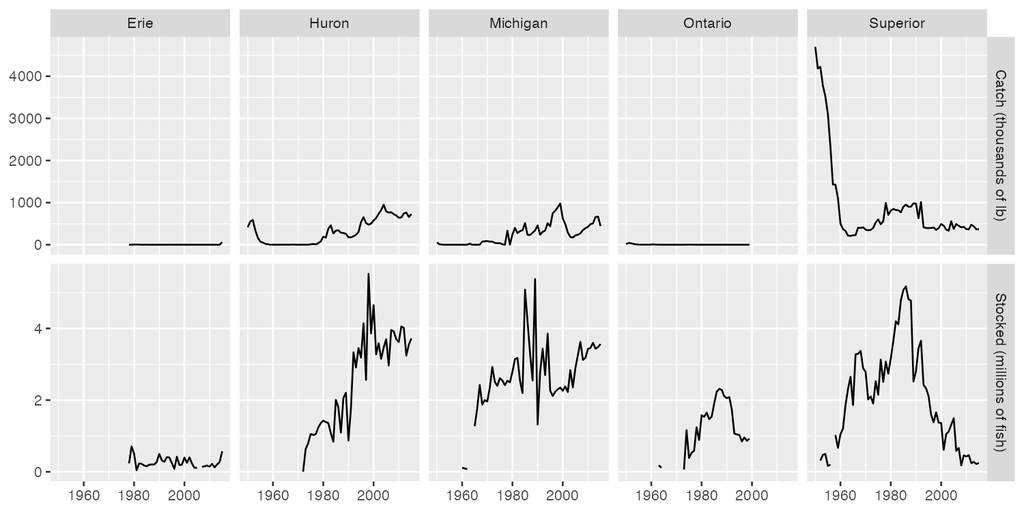

`pivot_longer()` (Module 06) + `facet_grid(measure ~ lake, scales = "free_y")`

Warning *Removed 37 rows containing missing values*: years with no stocking record. A warning, not an error.

## Your Project: One Figure Today (10 min)

In your **project** repo, `report.qmd`:

````markdown
```{r}
#| label: fig-trout
#| fig-cap: "Lake trout catch fell to near zero in Lakes Michigan and Huron by 1955."
#| fig-alt: "Line chart of lake trout catch, 1867 to 2015, one line
#|   per lake. Michigan, Huron and Superior drop sharply after 1945."
ggplot(trout, aes(x = year, y = catch, color = lake)) + geom_line()
```
````

- `fig-cap` = the **pattern** (the rubric checks this). `fig-alt` = what it shows, for a screen reader.
- Label starts with **`fig-`**: Quarto numbers it; refer to it as `@fig-trout`

## What Is Next

- **Proposal due Sun Nov 15**, 11:59 PM (rendered, pushed)
- **Assignment 08:** NOAA tornadoes, plots and a join. Opens **Wed Nov 11**, **due Sun Nov 22**
- **Draft due Sun Nov 29:** `report.qmd`, every section started, 3 figures

## Before You Leave

- Follow-along runs top to bottom after restarting R
- **Commit and push `class/`** in your **Module 05** repo
- One figure of **your own data** in your project `report.qmd`, pushed